# Problem Set 3: DiD

Romu Meango

MT 2025

# Difference-in-Difference (1)

Vella and Verbeek (REStat, 1998) analyse the effect of union membership on wages. One of the procedure they use is a Difference-in-Difference like procedure. Units of observations are individuals over the period 1980-1987. The initial DiD specification is a Two-Way Fixed Effect (TWFE) controlling for individual fixed effects and year fixed effects. The independent variable is the log-hourly wage (`lwage`), the treatment is measure by the indicator `union`, which is one if the worker is in a sector where the wage is determined by collective bargaining, and an important control is the number of hours worked (`hours`).

1. The data is called `wagepan` and available from the library `wooldridge`. Use the `R`-package `plm` to perform a TWFE to estimate the ATT of union membership on the wage.The individual identifier is in the variable `nr`.

```r
# For data
library("wooldridge")

# For a package way to do FE
library(plm)
library(lmtest)
# For analysis with heterogeneity
library(TwoWayFEWeights)
library(DIDmultiplegt)
#
library(ggplot2)

# panel of workers as in Vella and Verbeek (1998)
# https://www.jstor.org/stable/223257?seq=3#metadata_info_tab_contents
df<-wagepan

# Usual two way fixed effects (TWFE)
fit_plm <- plm(lwage ~ union + hours,
               data = wagepan,
               index = c("year", "nr"),
               model = "within",
               effect = "twoways")

# Note how this is functionally identical to the lm() way
coeftest(fit_plm, vcov = vcovHC, type = "HC1")
```

```
##
## t test of coefficients:
##
##          Estimate  Std. Error t value  Pr(>|t|)
## union  7.9470e-02  1.7994e-02  4.4164 1.032e-05 ***
## hours -1.1737e-04  3.3954e-05 -3.4569 0.0005523 ***
## ---
## Signif. codes:  0 '***' 0.001 '**' 0.01 '*' 0.05 '.' 0.1 ' ' 1
```

2. Using the library `TwoWayFEWeights`, compute the weights in a TWFE regression. Represent their density. Comment on the distribution of weights.

```r
Y = "lwage"
G = "nr"
T = "year"
D = "union"
controls = c("hours")

# Compute the weights in a TWFE regression
weight_inspect<- twowayfeweights(wagepan, Y, G, T, D, cmd_type = "feTR", controls = controls)
```

```
## [1] "Under the common trends assumption, "
## [1] "beta estimates a weighted sum of 1064 ATTs."
## [1] "875 ATT receive a positive weight, and 189 receive a negative weight."
## [1] "The sum of the positive weights is equal to 1.005601."
## [1] "The sum of the negative weights is equal to -0.005601."
## [1] "beta is compatible with a DGP where the average of those ATT is equal to 0,"
## [1] "while their standard deviation is equal to 0.087235."
## [1] "beta is compatible with a DGP where those ATT all are of a different sign than beta,"
## [1] "while their standard deviation is equal to 4.413974."
```

```r
summary(weight_inspect$weight)
```

```
##       Min.    1st Qu.     Median       Mean    3rd Qu.       Max.
## -0.0001099  0.0000000  0.0000000  0.0002294  0.0000000  0.0028450
```

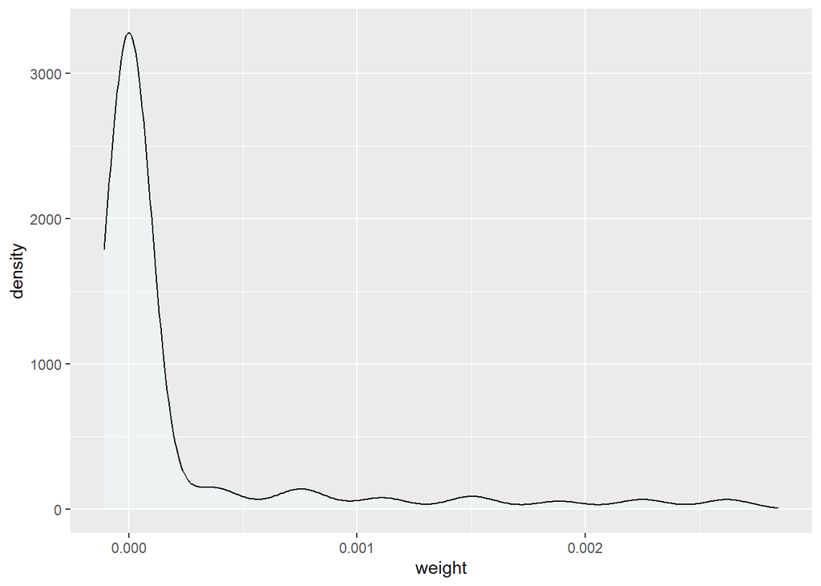

```r
# Density of weights
ggplot(weight_inspect, aes(x = weight, y = after_stat(density))) +
  geom_density(alpha = 0.4, fill = 'azure')
```

A non negligible part of the weights is negative, although small in magnitude. Note the warning that there might be sign reversal because of negative weights.

3. Using the library `DIDmultiplegt`, to measure the ATT. Comment on the difference with TWFE.

```r
# DID_M estimator from de Chaisemartin and d'Haultfoeuille
did_multiplegt(wagepan, Y, G, T, D, controls)
```

```
## $effect
##  treatment
## 0.02147226
##
## $N_effect
## [1] 3815
##
## $N_switchers_effect
## [1] 508
```

The effect is markedly smaller than the TWFE effect.

4. Use the options `placebo`, `dynamic`, `brep`, to visualise the treatment effect at from $t=t_d-1$ to $t = t_d + 2$, where $t_d$ is the time of the treatment (Note: depending on the configuration of your CPU, you may want to start with a low number of bootstrap replications e.g. `brep`=10).

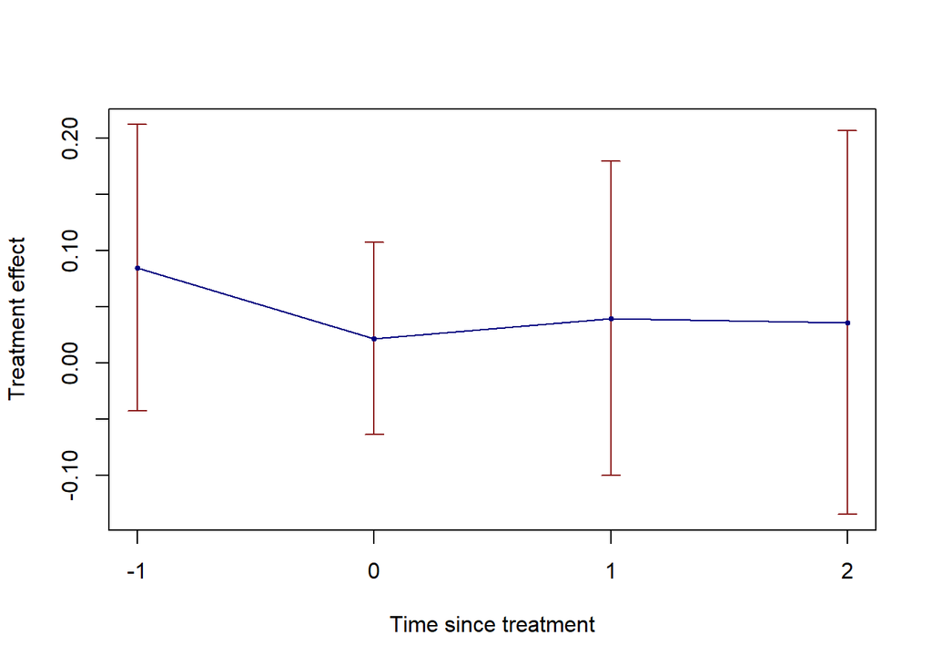

```
## $placebo_1
## [1] 0.08446127
##
## $se_placebo_1
## [1] 0.06500791
##
## $N_placebo_1
## [1] 2842
##
## $effect
## [1] 0.02147226
##
## $se_effect
## [1] 0.04363014
##
## $N_effect
## [1] 3815
##
## $N_switchers_effect
## [1] 508
##
## $dynamic_1
## [1] 0.03961501
##
## $se_dynamic_1
## [1] 0.07132453
##
## $N_dynamic_1
## [1] 2853
##
## $N_switchers_effect_1
## [1] 258
##
## $dynamic_2
## [1] 0.03582483
##
## $se_dynamic_2
## [1] 0.08707812
##
## $N_dynamic_2
## [1] 2201
##
## $N_switchers_effect_2
## [1] 190
```

```r
did_multiplegt(wagepan, Y, G, T, D, controls, placebo=1, dynamic=2, brep = 50)
```

The parallel-trend hypothesis seems to hold.

## Difference-in-Difference (2): The Occupational Cost of International Migration

The Migration between Africa and Europe project collected unique data on individual migration pattern between three African countries and three European destinations https://mafeproject.site.ined.fr/en/data/. The Data we will use here are constructed from the anonymised dataset with the addition of some noise, for copyright issues.

The data collects individual information on past and current migration episodes for natives from Senegal, stayers, current migrants and returnees. You can access the dataset here https://canvas.ox.ac.uk/courses/294247/files/8012421?wrap=1.

This is a panel data (with time `year` and identifier `newid`) describing respondents’ migration status in each year `immig_t`, occupational status in each year `isei` and `isco`, and an imputed measure of annual earnings `wage`. The data set also contains information about the age in each year `age_t`, the years since migration `ysm_t`, and additional demographics.

The `isei` is a socio-economic index of occupational status scales occupations by the average level of education and average earnings of job holders. This is designed as a metric proposed to measure the “status” of an occupation, higher status occupations such as architects, having a higher `isei` than “construction worker”. See more here https://www.sciencedirect.com/science/article/pii/S0049089X96900101.

You are interested in understanding the effect of international migration from Senegal to Europe on occupational status, and choose to adopt a Difference-in Difference approach.

1. What are the identifying assumptions? Is it a concern that migrants can self-select into migration based on their occupational gains or losses?
2. Present a data summary of pertinent variables for observation in 2008, and compare the stayers to the current migrants. Tipp: Some data cleaning: Set the years since migration to -99 for stayers. Drop the extreme values of wage.
3. What is the baseline regression you would perform to measure the $ATT$ of migration on occupational status `isei`? Present the results of the regression. Tipp: You will need to exclude duplicates.
4. What happens if you include `age_t` as a control in the two-way fixed effect regression controlling for year and individual fixed-effect? Can you explain the result?
5. Present also the regression for and the estimate of $ATT_{t}$, the $ATT$ after $t=0,1,\ldots,5$ years of migration.
6. Can you perform a placebo test to understand whether the parallel trend assumption holds up to two years before the treatment?
7. Check the sensitivity of the two-way fixed effects specification to the concern of heterogeneity raised by de Chaisemartin and d’Haultefoeuille (2022). Can you give one example of why negative weights would arise? Estimate the dynamic ATT using their package `DIDmultiplegt`. Tipp: limit the number of `brep` to 5 - it is just for illustration.
8. Write a short paragraph explaining your findings and its possible limitations (150 words).
9. Read the help of the `did` package. Using the same data as in previous question and the command `att_gt`, estimate group-time specific ATT. The groups are defined here as the year in which the individual migrates. Tipp: For simplicity, filter out observations with missing isei and use the observations from 2000-2008 only.
10. Using the command `aggte`, investigate the ATT over the groups.